# MSDS 6373 Covid Project

Balaji Avvaru

8/4/2020

### Time series analysis on COVID data for US

### Response variable is number of new daily cases

### EDA

1. Identify yourself and your partner (if applicable). Goal 1
2. Describe the Data Set / Time Series (Who, What, When, Where, Why and How) Goal 1
3. Stationary / Non-Stationary Goal 2
4. ACFs and Spectral Densities just to explore Goal 2
5. At least 2 (total) candidate ARMA / ARIMA models (univariate) Goal 2 a. The models in factored form or at least separate the stationary and non- stationary factors with standard deviation or variance of the white noise. b. AIC c. ASE (Rolling window) d. Visualization of Forecasts (Short and Long Term / State and National)
6. Strategy / Plans for the rest of the analysis.

****** Read Covid data ******** Covid data downloded from : https://covidtracking.com/data/download

```r
setwd("C:/Users/BelajiAvvaru/Desktop/Docs/SMU/MSDS 6373/Project/")
#Read in the data
USCovid19data <- read.csv(file.choose(),header=TRUE)
dim(USCovid19data)
```

```
## [1] 195  25
```

****** Read mobility data ******** Mobility data downloded from https://data.bts.gov/Research-and-Statistics/Trips-by-Distance/w96p-f2qv

```r
USmobilitydata <- read.csv(file.choose(),header=TRUE)
dim(USmobilitydata)
```

```
## [1] 1826968      19
```

### Describe Covid Data Set

There are three different correlation structures in the covid data, due to lack of tests and also lack of reporing, initial correlation structure is one kind. From 02/29 to 06/01, there is another correlation structure. After 06/01 I see different correlation structure as number of test increased which results in more number of positive cases. forecasting will following latest trend, using data from 06/01 to 07/25 which will helpful in creating accurate model for forecasting with latest trends.

*** tidy covid data **

```r
USCoviddata = USCovid19data[ , c('date', 'positive', 'negative', 'death')]
# Question on interest is to analyze Washington state Covid data, get Washington state data after 06/15/2020
Coviddata_US <- USCoviddata %>% filter(date >= 20200601 & date <= 20200725)
# Arrange the data in the ascending order based on date
Coviddata_US <-  Coviddata_US[order(Coviddata_US$date),]
# Create new column for "new cases" by taking first difference
Coviddata_US <- Coviddata_US %>% mutate(new_cases = c(positive[1],diff(positive)))
# Create new column for "Positive percentage"
Coviddata_US$positivePer <- (Coviddata_US$positive / (Coviddata_US$positive + Coviddata_US$negative)) * 100
# create new column for new negative cases
Coviddata_US <- Coviddata_US %>% mutate(new_negative = c(negative[1],diff(negative)))
# create new column for total cases
Coviddata_US$totalcases = Coviddata_US$new_cases + Coviddata_US$new_negative
Coviddata_US = transform(Coviddata_US, date=as.Date(as.character(date), "%Y%m%d"))


Coviddata_US$new_cases[1] = 20415
Coviddata_US$totalcases[1] = 374532
```

### Describe Mobility Data Set

This is a daily data set downloaded from https://data.bts.gov/Research-and-Statistics/Trips-by-Distance/w96p-f2qv. The data set is a record of the number of people staying at home, number of people not staying at home, number of people had trips less than 1 mile, number of people had trips between 1 and 3 miles, number of people had trips between 3 and 5 miles, number of people had trips between 5 and 10 miles and number of people had trips between 10 and 25 miles. Used this data set in multivariate analysis to better forecast number new Covid cases in Washington state and US.

*** tidy mobility data **

```r
USmobilitydata2020 = USmobilitydata[ , c('Date', 'Level', 'State.Postal.Code',  'Population.Staying.at.Home',
                                     'Population.Not.Staying.at.Home', 'Number.of.Trips',
                                     'Number.of.Trips..1', 'Number.of.Trips.3.5',
                                     'Number.of.Trips.1.3', 'Number.of.Trips.5.10',
                                     'Number.of.Trips.10.25')]
# remove rows with NA values
USmobilitydata2020 <- na.omit(USmobilitydata2020)

USmobilitydata2020$Date = as.Date(USmobilitydata2020$Date, format="%Y/%m/%d")

# Question on interest is to analyze Washington state Covid data, get Washington state data after 02/29/2020
mobilitydata2020_US <- USmobilitydata2020 %>% filter(Level == 'County' & Date >= '2020-06-01')
# Arrange the data in ascending order
mobilitydata2020_US <-  mobilitydata2020_US[order(mobilitydata2020_US$Date),]
dim(mobilitydata2020_US)
```

```
## [1] 172032     11
```

```r
# Group by date of mobility data
mobilitydata2020_US_Sum <- mobilitydata2020_US %>% dplyr::group_by(Date) %>%
  dplyr::summarize(athomeus = sum(Population.Staying.at.Home),
            notathomeus = sum(Population.Not.Staying.at.Home),
            num_tripsus = sum(Number.of.Trips),
            tripslessthan1mileus = sum(Number.of.Trips..1),
            trips1to3milesus = sum(Number.of.Trips.1.3),
            trips3to5milesus = sum (Number.of.Trips.3.5),
            trips5to10milesus = sum(Number.of.Trips.5.10),
            trips10to25milesus = sum (Number.of.Trips.10.25))
## data is missing for July 4th week from 06/28 to 7/4. Impute mean values for these dates
NA2mean <- function(x) replace(x, is.na(x), mean(x, na.rm = TRUE))
mobilitydata2020_US_Sum <- replace(mobilitydata2020_US_Sum, TRUE, lapply(mobilitydata2020_US_Sum, NA2mean))

# verify any null values
new_DF <- mobilitydata2020_US_Sum[rowSums(is.na(mobilitydata2020_US_Sum)) > 0,]
new_DF
```

```
## # A tibble: 0 x 9
## # ... with 9 variables: Date <date>, athomeus <dbl>, notathomeus <dbl>,
## #   num_tripsus <dbl>, tripslessthan1mileus <dbl>, trips1to3milesus <dbl>,
## #   trips3to5milesus <dbl>, trips5to10milesus <dbl>, trips10to25milesus <dbl>
```

```r
tail(mobilitydata2020_US_Sum)
```

```
## # A tibble: 6 x 9
##   Date       athomeus notathomeus num_tripsus tripslessthan1m~ trips1to3milesus
##   <date>        <dbl>       <dbl>       <dbl>            <dbl>            <dbl>
## 1 2020-07-20 86409289   240757453   930028975        239950654        224109776
## 2 2020-07-21 82985169   244181573   922315955        235380055        216594816
## 3 2020-07-22 81477784   245689562   924903198        233646773        217247618
## 4 2020-07-23 82416960   244749782   900816932        227670477        210502076
## 5 2020-07-24 78917609   248249133   968970946        244375413        228685042
## 6 2020-07-25 85536407   241630335   895712860        229803999        216971413
## # ... with 3 more variables: trips3to5milesus <dbl>, trips5to10milesus <dbl>,
## #   trips10to25milesus <dbl>
```

*** Merge Covid data and Mobility data by date **

```r
Covid_mobility_US <- merge(Coviddata_US, mobilitydata2020_US_Sum, by.x = "date",
                   by.y = "Date", all.x = TRUE)

dim(Covid_mobility_US)
```

```
## [1] 55 16
```

### check whether data comes from stationary model or non-Stationary model

Constant Mean:Number of new cases increasing over time. Last 10 days new cases increasing rapidly. Over this time frame, there is evidence that the condition is not met because the mean appears higher at the end of the series than at the beginning.

Constant Variance: Over this time frame, there is evidence that the condition is not met because the variance appears fluctuating over the time.

```r
dim(Coviddata_US)
```

```
## [1] 55  8
```

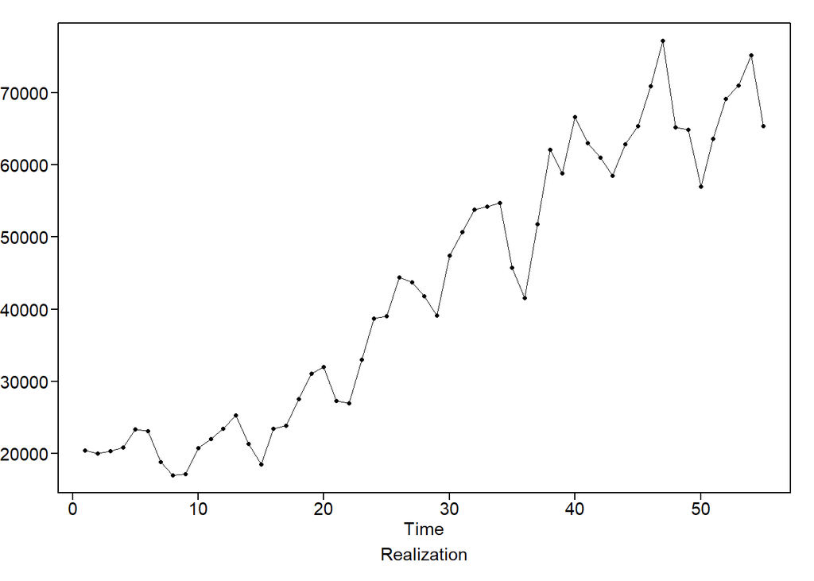

```r
# New cases Realization
plotts.wge(Coviddata_US$new_cases)
```

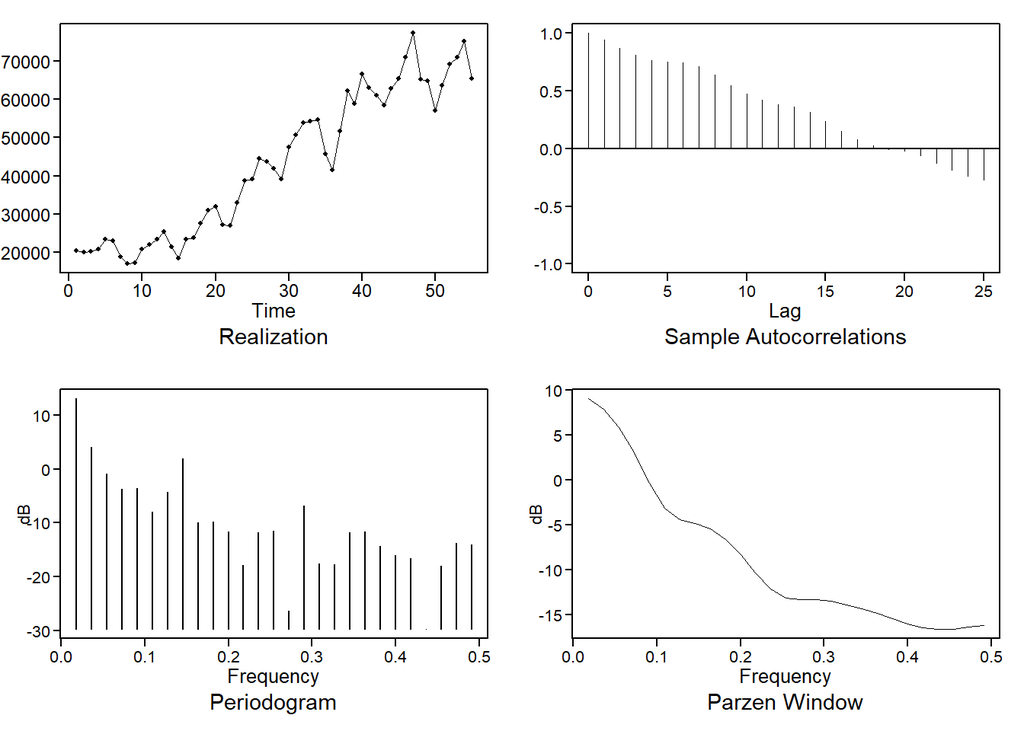

```
## $autplt
##  [1]  1.000000000  0.942122956  0.870365141  0.808972768  0.767835434
##  [6]  0.751592058  0.746766203  0.714683118  0.643127278  0.550472419
## [11]  0.475528637  0.420557908  0.384679362  0.359892856  0.316917281
## [16]  0.236149978  0.150727975  0.080595090  0.023322478 -0.004719254
## [21] -0.019917629 -0.057338334 -0.123347917 -0.186801351 -0.235482344
## [26] -0.273005172
##
## $freq
##  [1] 0.01818182 0.03636364 0.05454545 0.07272727 0.09090909 0.10909091
##  [7] 0.12727273 0.14545455 0.16363636 0.18181818 0.20000000 0.21818182
## [13] 0.23636364 0.25454545 0.27272727 0.29090909 0.30909091 0.32727273
## [19] 0.34545455 0.36363636 0.38181818 0.40000000 0.41818182 0.43636364
## [25] 0.45454545 0.47272727 0.49090909
##
## $db
##  [1]  13.0541567   4.0268347  -0.9438896  -3.7141440  -3.6023407  -7.9140273
##  [7]  -4.3428347   1.9887332  -9.9579817  -9.8461215 -11.6338761 -17.8809640
## [13] -11.8410267 -11.4340810 -26.3925594  -6.7734544 -17.5887379 -17.6970011
## [19] -11.7555986 -11.5819945 -14.2928523 -15.9869378 -16.6128488 -29.7785000
## [25] -17.9701625 -13.7161750 -14.0475921
##
## $dbz
##  [1]   9.001344   7.813106   5.806929   3.000432  -0.331718  -3.167464
##  [7]  -4.406734  -4.828190  -5.491004  -6.674553  -8.350520 -10.348087
## [13] -12.179163 -13.157942 -13.329033 -13.347829 -13.543125 -13.897453
## [19] -14.344042 -14.871358 -15.454860 -16.012552 -16.445687 -16.668515
## [25] -16.632514 -16.415010 -16.221033
```

```r
# Check ACF and Spectral density plots
plotts.sample.wge(Coviddata_US$new_cases)
```

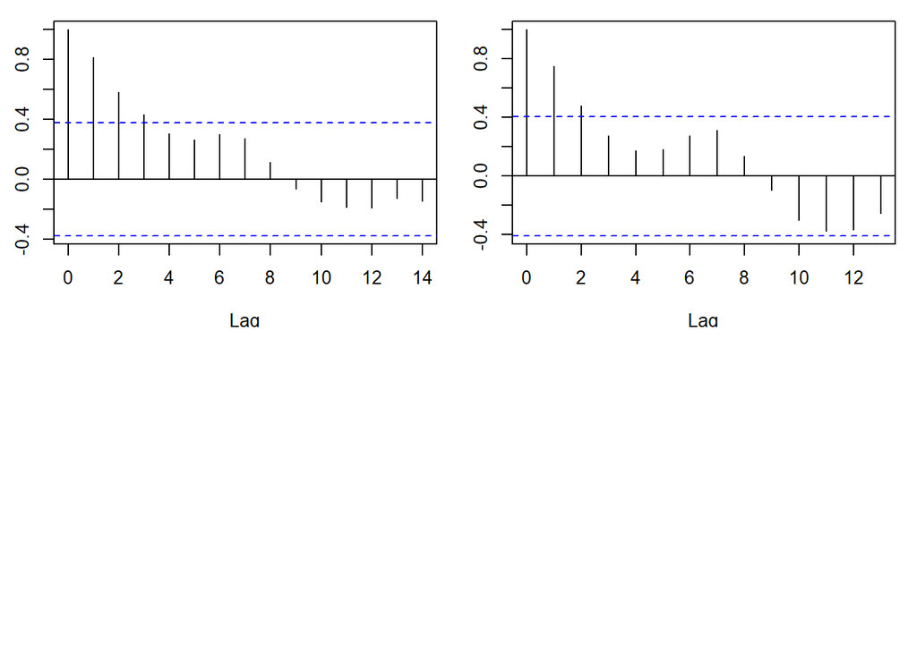

```r
# Auto correlations of first half of data
acf(Coviddata_US$new_cases[1:27])
# Auto correlations of second half of data
acf(Coviddata_US$new_cases[28:50])
```

### UNIVARIATE ANALYSIS

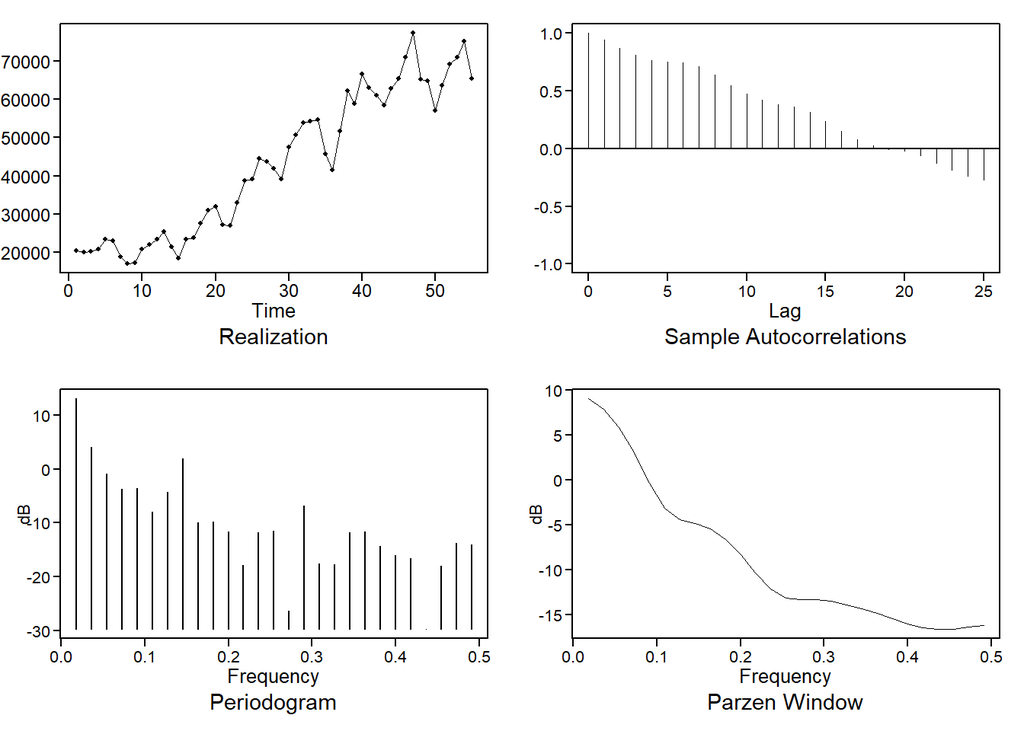

```
## $autplt
##  [1]  1.000000000  0.942122956  0.870365141  0.808972768  0.767835434
##  [6]  0.751592058  0.746766203  0.714683118  0.643127278  0.550472419
## [11]  0.475528637  0.420557908  0.384679362  0.359892856  0.316917281
## [16]  0.236149978  0.150727975  0.080595090  0.023322478 -0.004719254
## [21] -0.019917629 -0.057338334 -0.123347917 -0.186801351 -0.235482344
## [26] -0.273005172
##
## $freq
##  [1] 0.01818182 0.03636364 0.05454545 0.07272727 0.09090909 0.10909091
##  [7] 0.12727273 0.14545455 0.16363636 0.18181818 0.20000000 0.21818182
## [13] 0.23636364 0.25454545 0.27272727 0.29090909 0.30909091 0.32727273
## [19] 0.34545455 0.36363636 0.38181818 0.40000000 0.41818182 0.43636364
## [25] 0.45454545 0.47272727 0.49090909
##
## $db
##  [1]  13.0541567   4.0268347  -0.9438896  -3.7141440  -3.6023407  -7.9140273
##  [7]  -4.3428347   1.9887332  -9.9579817  -9.8461215 -11.6338761 -17.8809640
## [13] -11.8410267 -11.4340810 -26.3925594  -6.7734544 -17.5887379 -17.6970011
## [19] -11.7555986 -11.5819945 -14.2928523 -15.9869378 -16.6128488 -29.7785000
## [25] -17.9701625 -13.7161750 -14.0475921
##
## $dbz
##  [1]   9.001344   7.813106   5.806929   3.000432  -0.331718  -3.167464
##  [7]  -4.406734  -4.828190  -5.491004  -6.674553  -8.350520 -10.348087
## [13] -12.179163 -13.157942 -13.329033 -13.347829 -13.543125 -13.897453
## [19] -14.344042 -14.871358 -15.454860 -16.012552 -16.445687 -16.668515
## [25] -16.632514 -16.415010 -16.221033
```

```r
## Auto correlations are slowly damping.
## Dickey-Fuller test to see whether there is any root on unit circle or not
plotts.sample.wge(Coviddata_US$new_cases)
```

```r
adf.test(Coviddata_US$new_cases)
```

```
##
##  Augmented Dickey-Fuller Test
##
## data:  Coviddata_US$new_cases
## Dickey-Fuller = -3.0604, Lag order = 3, p-value = 0.1472
## alternative hypothesis: stationary
```

```r
## p-value = 0.147, fail to reject null, which is evident that there is a root on unit circle. Proceed with ARIMA model

Coviddata_US.d1 = artrans.wge(Coviddata_US$new_cases,phi.tr = 1)
```

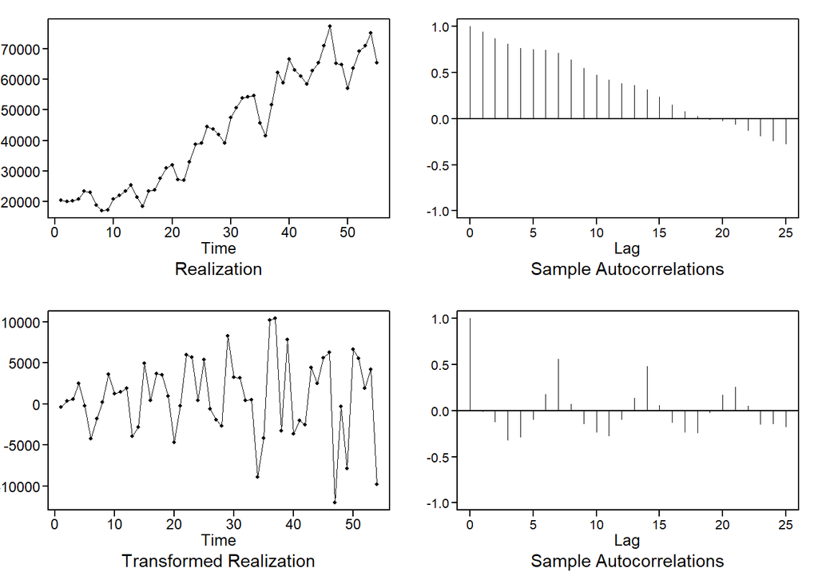

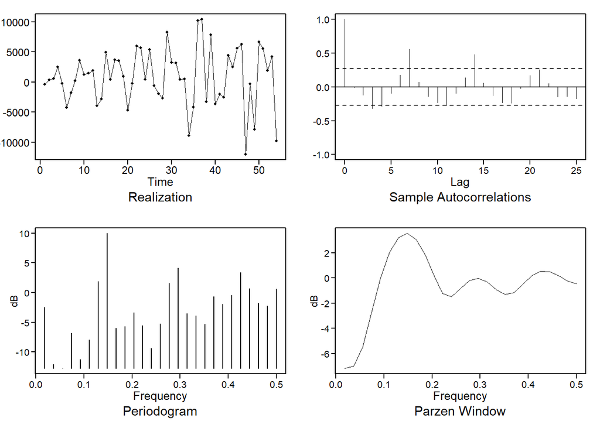

```
## $autplt
##  [1]  1.000000000 -0.004588261 -0.119967229 -0.317629642 -0.282900486
##  [6] -0.091183808  0.177804301  0.561196238  0.073501767 -0.141301210
## [11] -0.231778425 -0.268472759 -0.092018310  0.138118565  0.480606678
## [16]  0.061063171 -0.126866823 -0.234864672 -0.237993220 -0.018134604
## [21]  0.168770118  0.259223410  0.053128562 -0.149170635 -0.136213197
## [26] -0.171910211
##
## $freq
##  [1] 0.01851852 0.03703704 0.05555556 0.07407407 0.09259259 0.11111111
##  [7] 0.12962963 0.14814815 0.16666667 0.18518519 0.20370370 0.22222222
## [13] 0.24074074 0.25925926 0.27777778 0.29629630 0.31481481 0.33333333
## [19] 0.35185185 0.37037037 0.38888889 0.40740741 0.42592593 0.44444444
## [25] 0.46296296 0.48148148 0.50000000
##
## $db
##  [1]  -2.4886952 -12.0551049 -12.7656457  -6.8542494 -11.2104851  -7.9468459
##  [7]   1.9209252   9.9521971  -5.9893145  -5.6647549  -3.3907973  -5.5597123
## [13]  -9.3722612  -5.2564551   1.5497892   4.1577054  -3.5316265  -3.9269235
## [19]  -5.2866936  -0.6913760  -1.9372423  -0.4629093   3.4048851   0.6787602
## [25]  -1.8165496  -2.2364794   0.5992392
##
## $dbz
##  [1] -7.191384204 -7.011018620 -5.488552223 -2.724641798  0.001811614
##  [6]  2.025696616  3.205349701  3.543731380  3.072743612  1.866423080
## [11]  0.182967889 -1.237890752 -1.479238949 -0.820838683 -0.186516463
## [16] -0.007319622 -0.314291241 -0.897428925 -1.312838489 -1.140617492
## [21] -0.485703754  0.186584290  0.550993243  0.519983789  0.178573811
## [26] -0.243088625 -0.436732379
```

```r
## ACFs of  differenced  data with d=1 doesn't look like white
plotts.sample.wge(Coviddata_US.d1, arlimits = T)
```

```r
# use AIC5 to get lowest AIC to model the differenced data
aic5.wge(Coviddata_US.d1, p=0:7, q=0:2,type="aic")
```

```
## ---------WORKING... PLEASE WAIT...
##
##
## Error in aic calculation at 3 2
## Error in aic calculation at 4 2
## Error in aic calculation at 5 2
## Five Smallest Values of  aic
```

```
##       p    q        aic
## 23    7    1   16.47058
## 22    7    0   16.49745
## 24    7    2   16.54984
## 21    6    2   16.65957
## 16    5    0   16.74802
```

```r
## Top 2 models are ARMA(7,1) and AR(7)

aic5.wge(Coviddata_US.d1, p=0:7, q=0:2,type="bic")
```

```
## ---------WORKING... PLEASE WAIT...
##
##
## Error in aic calculation at 3 2
## Error in aic calculation at 4 2
## Error in aic calculation at 5 2
## Five Smallest Values of  bic
```

```
##       p    q        bic
## 22    7    0   16.79212
## 23    7    1   16.80208
## 24    7    2   16.91817
## 16    5    0   16.96902
## 21    6    2   16.99107
```

```r
## Top 2 models are AR(7) and ARMA(7,1)

# Selected AR(7)

# AR(2) model estimates
ar7.est=est.ar.wge(Coviddata_US.d1,p=7)
```

```
##
## Coefficients of Original polynomial:
## -0.2481 -0.1010 -0.2420 -0.2049 -0.1787 0.0221 0.5133
##
## Factor                 Roots                Abs Recip    System Freq
## 1-1.1739B+0.9375B^2    0.6261+-0.8214i      0.9683       0.1463
## 1+1.6980B+0.8510B^2   -0.9976+-0.4241i      0.9225       0.4360
## 1+0.4961B+0.8334B^2   -0.2977+-1.0542i      0.9129       0.2938
## 1-0.7720B              1.2953               0.7720       0.0000
##
##
##
## Coefficients of Original polynomial:
## -0.2481 -0.1010 -0.2420 -0.2049 -0.1787 0.0221 0.5133
##
## Factor                 Roots                Abs Recip    System Freq
## 1-1.1739B+0.9375B^2    0.6261+-0.8214i      0.9683       0.1463
## 1+1.6980B+0.8510B^2   -0.9976+-0.4241i      0.9225       0.4360
## 1+0.4961B+0.8334B^2   -0.2977+-1.0542i      0.9129       0.2938
## 1-0.7720B              1.2953               0.7720       0.0000
##
##
```

```r
Coviddata_US.d1.AR7 = artrans.wge(Coviddata_US.d1,phi.tr = ar7.est$phi)
```

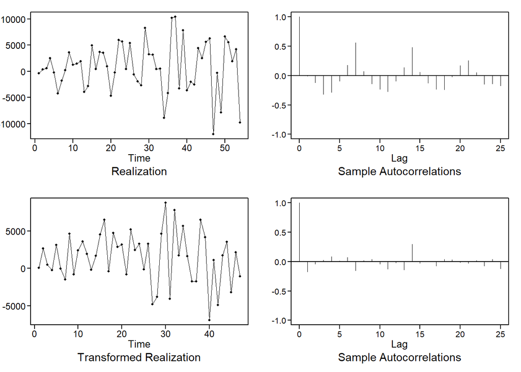

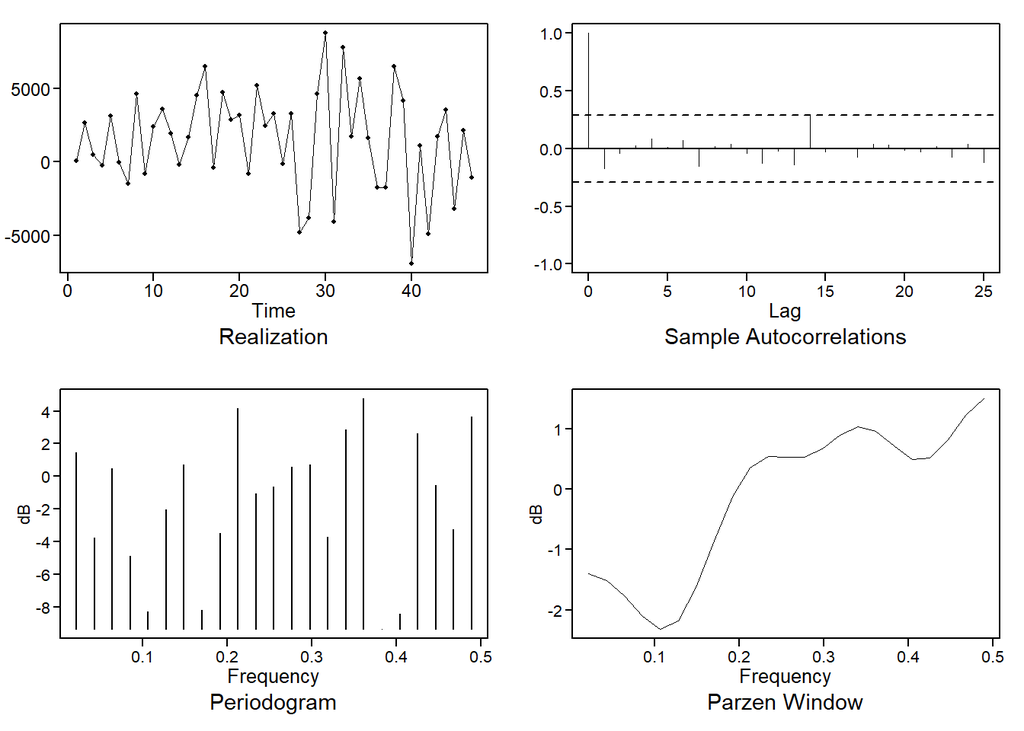

```
## $autplt
##  [1]  1.000000000 -0.172500331 -0.040274632  0.023226716  0.082896919
##  [6]  0.009477706  0.071133289 -0.150387200  0.017451785  0.036321265
## [11] -0.041874050 -0.123943178 -0.017934241 -0.138571788  0.299040038
## [16] -0.025312235 -0.002547696 -0.074257864  0.039384629  0.033053990
## [21] -0.012721911 -0.030106045  0.017853634 -0.074346407  0.036457047
## [26] -0.117000452
##
## $freq
##  [1] 0.02127660 0.04255319 0.06382979 0.08510638 0.10638298 0.12765957
##  [7] 0.14893617 0.17021277 0.19148936 0.21276596 0.23404255 0.25531915
## [13] 0.27659574 0.29787234 0.31914894 0.34042553 0.36170213 0.38297872
## [19] 0.40425532 0.42553191 0.44680851 0.46808511 0.48936170
##
## $db
##  [1]  1.4461335 -3.7514088  0.5017238 -4.8918829 -8.2796648 -2.0276812
##  [7]  0.7152911 -8.2198253 -3.4915949  4.1654237 -1.0668984 -0.6426439
## [13]  0.5502978  0.7246904 -3.7115101  2.8711387  4.7531627 -9.3874956
## [19] -8.4259660  2.6261764 -0.5433904 -3.2591501  3.6531792
##
## $dbz
##  [1] -1.3965242 -1.5102175 -1.7638357 -2.1028415 -2.3228938 -2.1837752
##  [7] -1.6312441 -0.8571741 -0.1319039  0.3524272  0.5415973  0.5319291
## [13]  0.5242578  0.6644531  0.8943446  1.0319607  0.9602099  0.7189232
## [19]  0.4961956  0.5122379  0.8145122  1.2209353  1.4937987
```

```r
## ACFs of  differenced  data with AR(2) shows white
plotts.sample.wge(Coviddata_US.d1.AR7, arlimits = T)
```

```r
ljung.wge(Coviddata_US.d1.AR7, K=24)
```

```
## Obs -0.1725003 -0.04027463 0.02322672 0.08289692 0.009477706 0.07113329 -0.1503872 0.01745179 0.03632126 -0.04187405 -0.1239432 -0.01793424 -0.1385718 0.29904 -0.02531223 -0.002547696 -0.07425786 0.03938463 0.03305399 -0.01272191 -0.03010604 0.01785363 -0.07434641 0.03645705
```

```
## $test
## [1] "Ljung-Box test"
##
## $K
## [1] 24
##
## $chi.square
## [1] 13.78264
##
## $df
## [1] 24
##
## $pval
## [1] 0.9514083
```

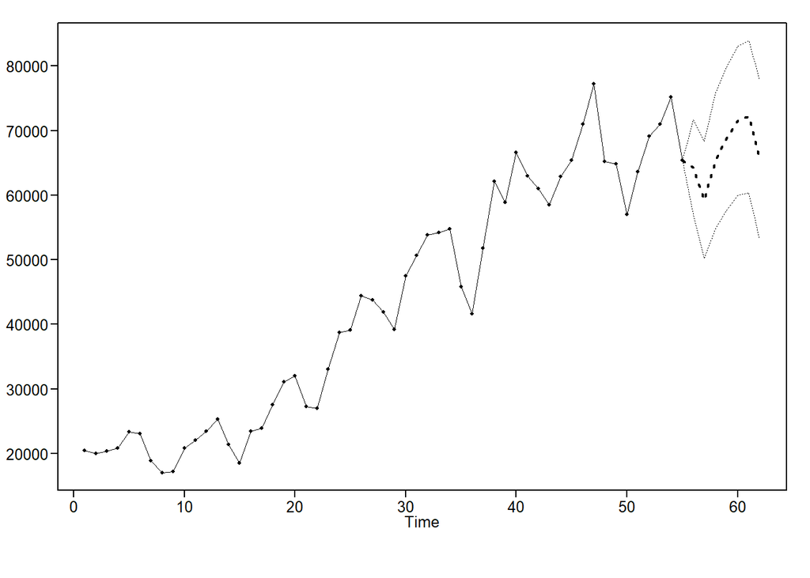

```
## $f
## [1] 64317.08 59286.01 65368.75 68761.52 71550.04 72192.41 65538.29
##
## $ll
## [1] 57024.44 50162.00 54869.32 57634.25 60017.00 60394.84 53205.09
##
## $ul
## [1] 71609.72 68410.02 75868.18 79888.80 83083.08 83989.98 77871.50
##
## $resid
##  [1]     0.00000     0.00000     0.00000     0.00000     0.00000     0.00000
##  [7]     0.00000     0.00000    45.39614  2666.61615   459.80819  -264.89324
## [13]  3155.40911   -50.97600 -1483.47970  4616.50203  -838.81713  2424.71799
## [19]  3583.06237  1924.87753  -165.14206  1699.37233  4527.35268  6503.43837
## [25]  -413.99039  4746.72603  2898.78930  3206.86101  -834.38406  5230.70746
## [31]  2440.63463  3311.30265  -116.42449  3294.16265 -4828.61190 -3847.51098
## [37]  4666.00208  8772.84662 -4089.95117  7824.68632  1747.06332  5683.99849
## [43]  1607.44589 -1734.29444 -1752.45528  6491.18839  4177.75595 -6958.40381
## [49]  1094.59413 -4903.61458  1722.18590  3536.36748 -3209.75531  2171.03150
## [55] -1077.14194
##
## $wnv
## [1] 13843871
##
## $se
## [1] 3720.735 4655.107 5356.852 5677.182 5884.204 6019.167 6292.452
##
## $psi
## [1] 0.7518745 0.7123941 0.5052864 0.4157996 0.3406537 0.4929886 1.0417651
##
## $ptot
## [1] 8
##
## $phitot
## [1]  0.75187447  0.14707893 -0.14092948  0.03707075  0.02623246  0.20078168
## [7]  0.49121312 -0.51332193
```

```r
## $pval  :0.951

## Ljung box test with K=24  fail to reject null hypothesis which is evident that the residuals are white

# Next 7 forecasts with AR(2) model
fore.aruma.wge(Coviddata_US$new_cases, phi = ar7.est$phi,d=1, n.ahead = 7, limits=T)
```

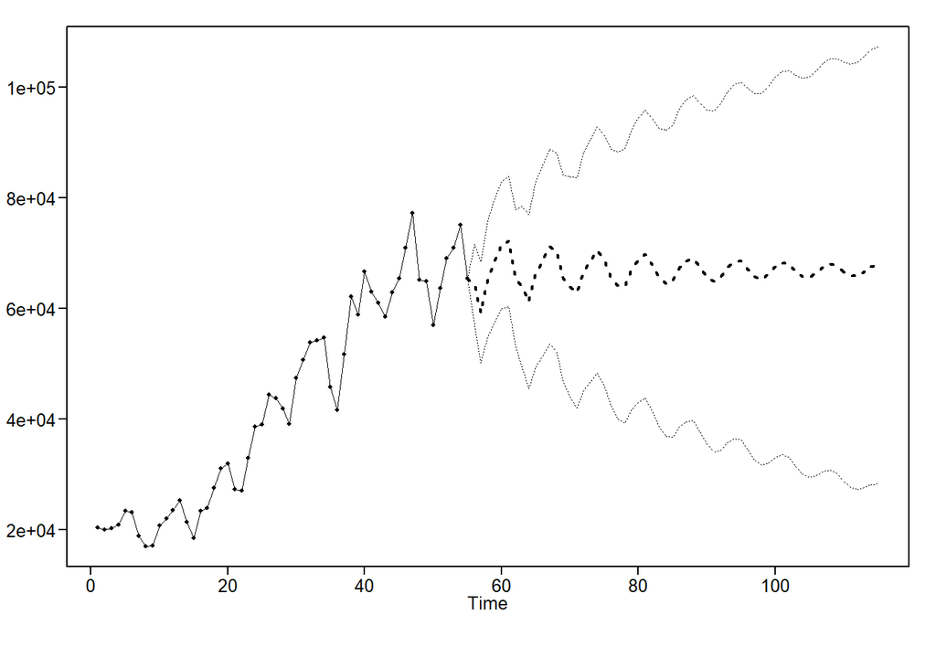

```
## $f
##  [1] 64317.08 59286.01 65368.75 68761.52 71550.04 72192.41 65538.29 63993.88
##  [9] 61268.37 66278.39 68736.32 71230.68 70168.14 65595.52 63982.06 62862.98
## [17] 66808.30 68776.52 70564.81 68838.60 65618.59 64198.07 64088.30 67141.16
## [25] 68756.58 69820.04 67973.23 65642.88 64542.30 65002.34 67354.52 68650.93
## [33] 69127.21 67411.71 65690.82 64935.22 65670.63 67483.43 68477.29 68538.42
## [41] 67049.84 65769.60 65323.73 66151.41 67547.50 68265.17 68064.32 66821.46
## [49] 65875.50 65677.33 66491.49 67561.46 68041.51 67696.32 66684.24 65999.41
## [57] 65981.86 66726.85 67538.40 67825.95
##
## $ll
##  [1] 57024.44 50162.00 54869.32 57634.25 60017.00 60394.84 53205.09 49508.52
##  [9] 45553.74 49513.46 51461.18 53583.11 52212.43 47002.57 44106.28 42091.58
## [17] 45272.92 46833.34 48288.84 46231.51 42394.15 40076.91 39258.41 41726.24
## [25] 42989.89 43739.24 41544.22 38645.94 36852.82 36725.66 38604.56 39579.73
```

[output cut: 59 more lines]

```r
# Next 60 forecasts with AR(2) model
fore.aruma.wge(Coviddata_US$new_cases, phi = ar7.est$phi,d=1, n.ahead = 60, limits=T)
```

```r
# ASE
Coviddata_US.d1.ar7.forecasts = fore.aruma.wge(Coviddata_US$new_cases, phi = ar7.est$phi, d=1,lastn = T, n.ahead = 7)
```

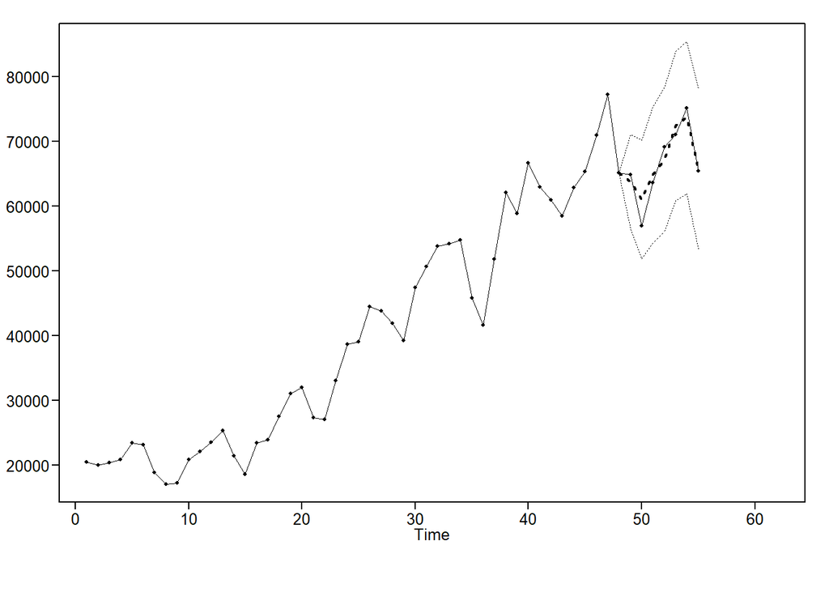

```r
Coviddata_US.d1.ar7.ase = mean((Coviddata_US$new_cases[(49-7+1):55] - Coviddata_US.d1.ar7.forecasts$f)^2)
Coviddata_US.d1.ar7.ase
```

```
## [1] 23518917
```

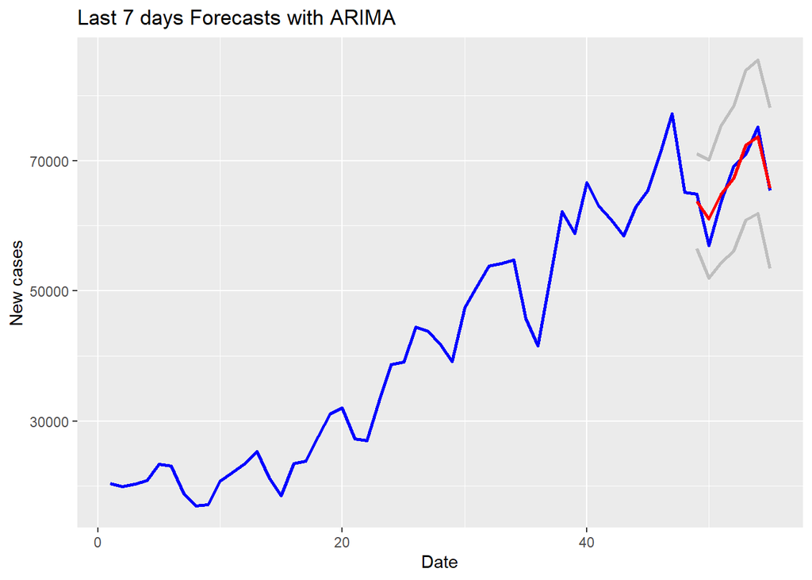

```r
# ASE : 23518917
#Plot
ggplot() +
  geom_line(aes(x=seq(1,55,1), y=Coviddata_US$new_cases, group = 1),
             color = "blue", size=1) +
  geom_line(aes(x=seq(49,55,1), y=Coviddata_US.d1.ar7.forecasts$f, group = 1),
             color = "red", size=1) +
  geom_line(aes(x=seq(49,55,1), y=Coviddata_US.d1.ar7.forecasts$ll, group = 1),
             color = "grey", size=1) +
  geom_line(aes(x=seq(49,55,1), y=Coviddata_US.d1.ar7.forecasts$ul, group = 1),
             color = "grey", size=1) +
  xlab("Date") +
  ylab("New cases") +
  ggtitle("Last 7 days Forecasts with ARIMA")
```

```r
# Rolling window ASE

trainingSize = 20
horizon = 7
US.d1.ar7.ASEHolder = numeric()

for( i in 1:(55-(trainingSize + horizon) + 1))
{

  forecasts = fore.aruma.wge(Coviddata_US$new_cases[i:(i+(trainingSize-1))],
                            phi = ar7.est$phi, d=1,n.ahead = horizon, plot=F)

  ASE = mean((Coviddata_US$new_cases[(trainingSize+i):(trainingSize+ i + (horizon) - 1)] - forecasts$f)^2)

  US.d1.ar7.ASEHolder[i] = ASE

}

US.d1.ar7.ASEHolder
```

```
##  [1]  73289811 101028063 100847007  86508820  52818450  80109654  55751304
##  [8]  53205705  35130251  39595304  15675729  23587794  17556685  37313808
## [15]  41850153  78517574 138705235 107625073  43511807  87378401  41804503
## [22]  32616982  12780769  15638520  16951555  22983005  13294523  26847985
## [29]   3852239
```

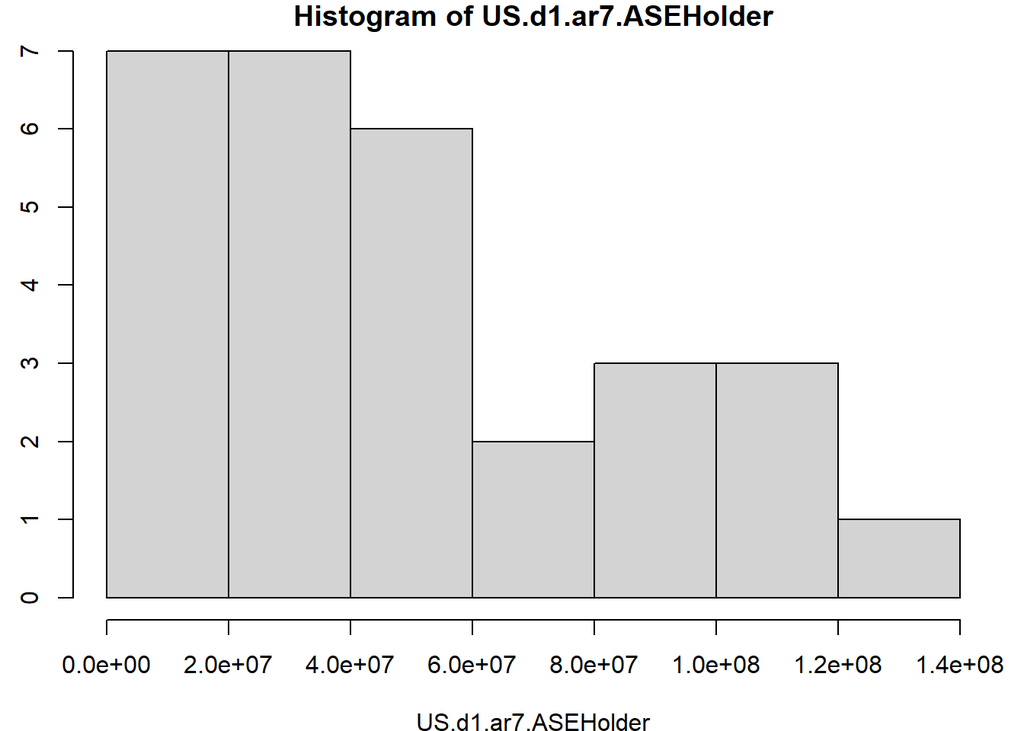

```r
hist(US.d1.ar7.ASEHolder)
```

```r
US.d1.ar7.WindowedASE = mean(US.d1.ar7.ASEHolder)

summary(US.d1.ar7.ASEHolder)
```

```
##      Min.   1st Qu.    Median      Mean   3rd Qu.      Max.
##   3852239  22983005  41804503  50233680  78517574 138705235
```

```r
US.d1.ar7.WindowedASE
```

```
## [1] 50233680
```

```r
## Rolling window ASE :50233680
```

```r
# univariate MLP model
fit.mlp.uni.US = mlp(ts(Coviddata_US$new_cases),reps = 100,comb = "median")
fit.mlp.uni.US
```

```
## MLP fit with 5 hidden nodes and 100 repetitions.
## Univariate lags: (1,3,4)
## Forecast combined using the median operator.
## MSE: 17338195.2766.
```

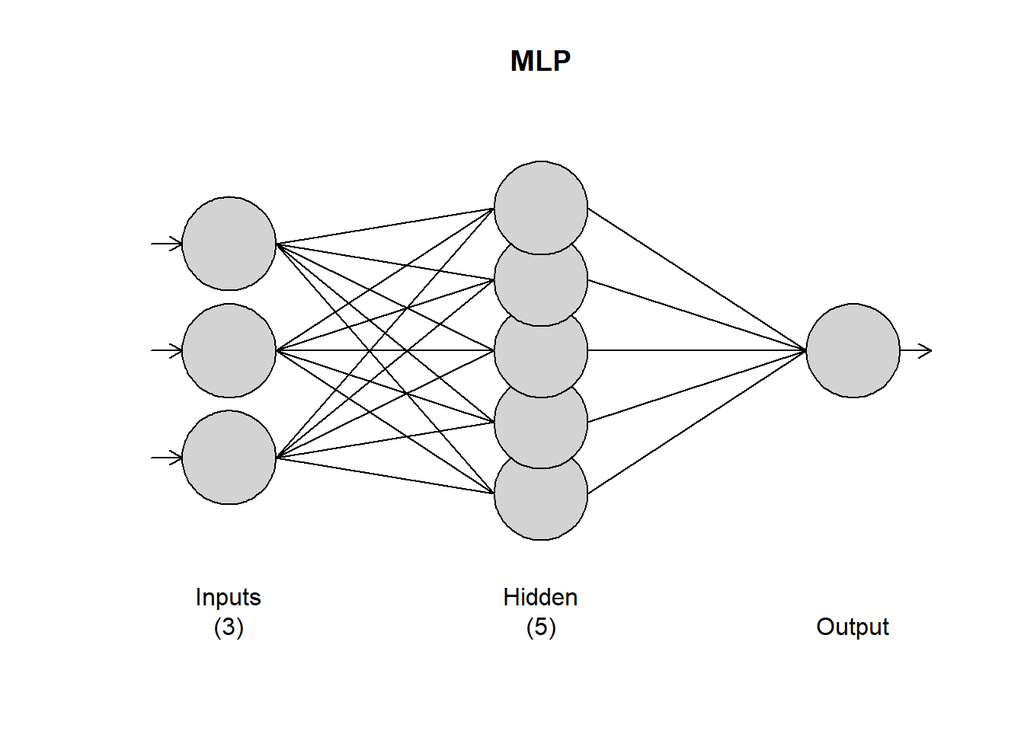

```r
plot(fit.mlp.uni.US)
```